# HW2: 各地區人口數與垃圾生產量的關係

chanyayun

2019/7/15

## 目的

> 利用政府資料開放平台所提供的資料，建立各地區人口數與各地區垃圾生產量的關係

使用資料：

- [1-1 土地面積、戶數、人口數、人口密度、年齡結構及扶養比例](https://data.gov.tw/dataset/6326)
- [垃圾清理量資料](https://data.gov.tw/dataset/89022)

## 步驟

> 1. 匯入dplyr並讀取資料

```r
library(dplyr)
library(readr)

garbage_file <- read.csv("garbage.csv")
popularity_file <- read_csv("popularity.csv")
```

> 2. 將popularity_file中包含“區”(如北部區域)、“省”(如福建省)的「地區」篩掉，並選擇「地區」與「年底人口數」

人口相關資料(前5筆)

[output not shown]

```r
p <- data.frame(popularity_file) %>%
  filter(!grepl("區", `地區`), !grepl("省", `地區`)) %>%
  select(`地區`, `年底人口數`)
```

> 3. 從garbage_file中選擇“county”(縣市)與“GarbageGenerated”(垃圾產生量)，並重新用中文命名欄位

垃圾清理資料(前5筆)

| year | month | county | GarbageGenerated | GarbageClearance | GarbageRecycled | FoodWastesRecycled | BulkWasteRecyclingandReuse |
| --- | --- | --- | --- | --- | --- | --- | --- |
| 107 | 9 | 連江縣 | 657 | 160 | 302 | 159 | 36 |
| 107 | 9 | 金門縣 | 2,316 | 555 | 1,235 | 488 | 39 |
| 107 | 9 | 嘉義市 | 11,816 | 5,194 | 5,691 | 867 | 64 |
| 107 | 9 | 新竹市 | 15,032 | 5,029 | 8,310 | 1,334 | 358 |
| 107 | 9 | 基隆市 | 15,314 | 6,108 | 8,156 | 975 | 76 |

> > 為配合popularity_file的年底人口數，選擇最近期的年底(2017年11月)

```r
g <- data.frame(garbage_file) %>%
  filter(year == "106", month == "11") %>%
  select(county, GarbageGenerated) %>%
  rename(
    `地區` = county,
    `垃圾生產量(t)` = GarbageGenerated
  )
```

> 4. 檢查資料型態是否會影響後續操作

```r
str(g)
```

```
## 'data.frame':    22 obs. of  2 variables:
##  $ 地區         : Factor w/ 22 levels "宜蘭縣","花蓮縣",..: 10 3 15 13 9 22 2 20 5 16 ...
##  $ 垃圾生產量(t): Factor w/ 482 levels "10,167","10,607",..: 347 201 5 139 87 246 1 366 238 114 ...
```

> > 將「垃圾生產量」的資料型態改為numeric，以利之後的計算

```r
g$`垃圾生產量(t)` <- as.numeric(gsub(",", "", g$`垃圾生產量(t)`))
```

```r
merged_data <- merge(p, g, by = "地區")
#merged_data <- merged_data[order(merged_data), ]
#Error: unexpected input in "merged_data <- merged_data[order(merged_data$\"
```

> > 加入新的欄位“單位垃圾生產量(kg/人)”

```r
merged_data <- mutate(merged_data, `單位垃圾生產量(kg/人)` = (`垃圾生產量(t)`/年底人口數)*1000)
```

最終合併資料

| 地區 | 年底人口數 | 垃圾生產量(t) | 單位垃圾生產量(kg/人) |
| --- | --- | --- | --- |
| 宜蘭縣 | 456607 | 12643 | 27.68902 |
| 花蓮縣 | 329237 | 10167 | 30.88049 |
| 金門縣 | 137456 | 2392 | 17.40193 |
| 南投縣 | 501051 | 14553 | 29.04495 |
| 屏東縣 | 829939 | 26712 | 32.18550 |
| 苗栗縣 | 553807 | 20951 | 37.83087 |
| 桃園市 | 2188017 | 75418 | 34.46865 |
| 高雄市 | 2776912 | 83391 | 30.03012 |
| 基隆市 | 371458 | 14745 | 39.69493 |
| 連江縣 | 12880 | 650 | 50.46584 |
| 雲林縣 | 690373 | 15835 | 22.93688 |
| 新北市 | 3986689 | 155242 | 38.94008 |
| 新竹市 | 441132 | 15674 | 35.53131 |
| 新竹縣 | 552169 | 14704 | 26.62953 |
| 嘉義市 | 269398 | 10833 | 40.21188 |
| 嘉義縣 | 511182 | 15218 | 29.77022 |
| 彰化縣 | 1282458 | 34810 | 27.14319 |
| 臺中市 | 2787070 | 70623 | 25.33951 |
| 臺北市 | 2683257 | 59621 | 22.21964 |
| 臺東縣 | 219540 | 7227 | 32.91883 |
| 臺南市 | 1886522 | 58778 | 31.15681 |
| 澎湖縣 | 104073 | 3195 | 30.69961 |

## 結論

> 利用`plot()`簡單的呈現結果

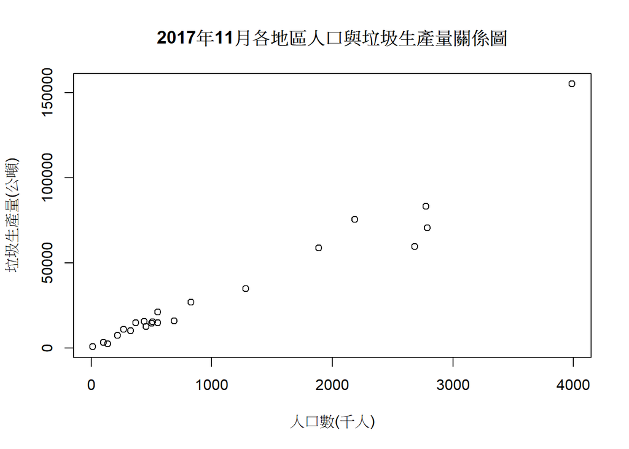

> 由上圖可知，人口數與垃圾生產量有顯著的正相關，人口越多的地區會產生越多的垃圾。 但若考慮下圖人口數與單位垃圾生產量(公斤/人)的關係，可以得知，人口數少的地區所產生的垃圾量，就比例而言偏多。  
> 註：為避免橫坐標數值出現科學記號，故將人口數以千人為單位表示

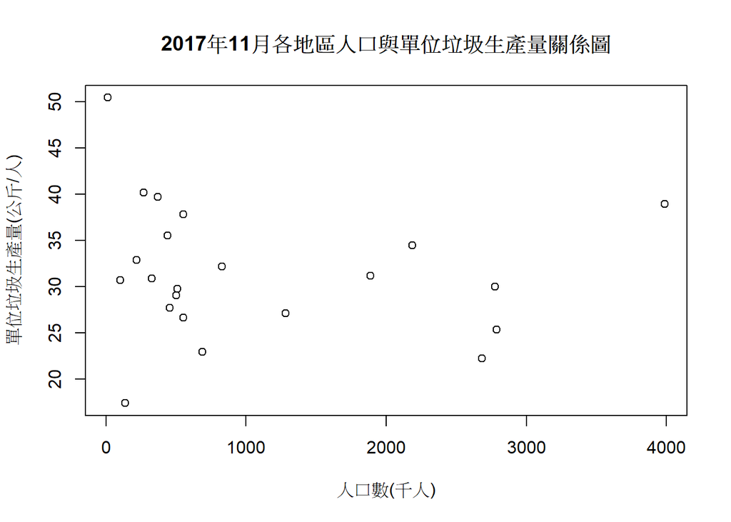